# CheapMass

Alain Duplan & Ariel Lutati

## set up

```
## [1] "Year" "2019" "2018" "2017" "2016" "2015" "Nets"
```

## linear model

note that all together, a proper linear could not be created using all the variables

V3, V5, significant under 5% interval and V11 is significant under 1% interval. So we will use these three models of linear regresssion to try to predict tuittion and fees

V11 - sumplimental disclosures of non cash activities V5 - net decrease in cash and noncash equivalents V3 - cash flows from capital and other financing activities

We also found that cash from non financing activities is important to umass since that is what they are using for refunds this semester

V7 and V2 are the only significant variables in this catergory so we will also use it V2 - grants and contracts v7 - student orginzation agency transactions

plot tuitiin and fees on its , if you want we can plot the other variables but that would be a lot of graphs

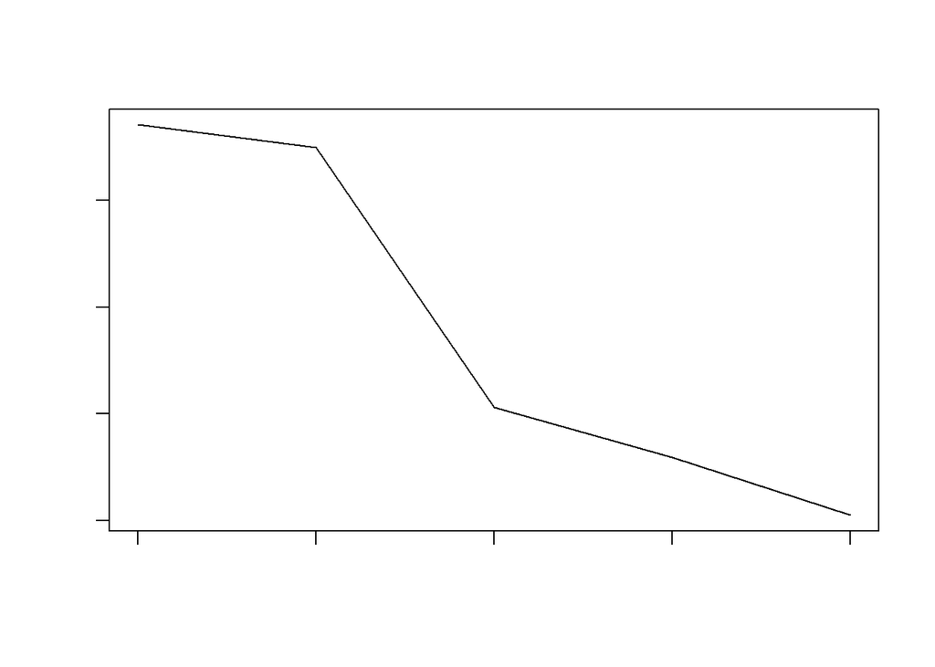

make our predictions

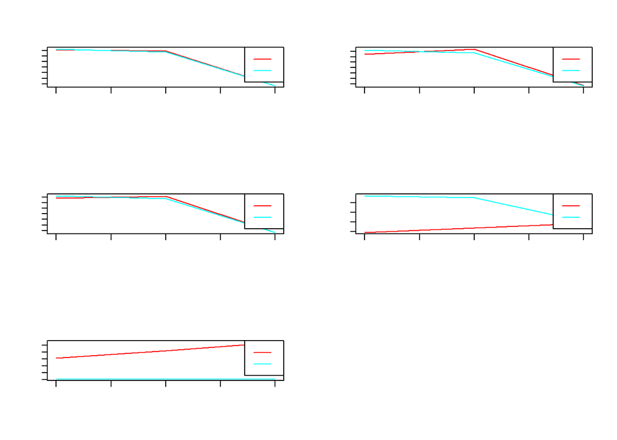

we have to add some labels lol but we can work on it after

v11 is by far the closest predictors, follows by v5, v3 is meh and everything else goes to shit from there

we will now plot the residual time series see how much we are off by

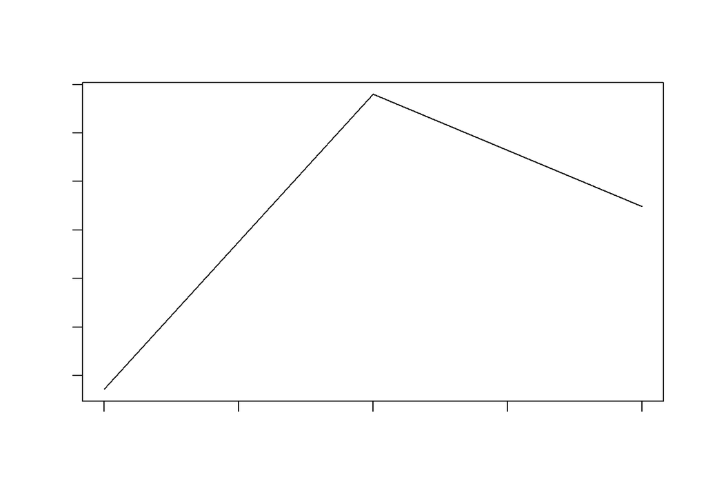

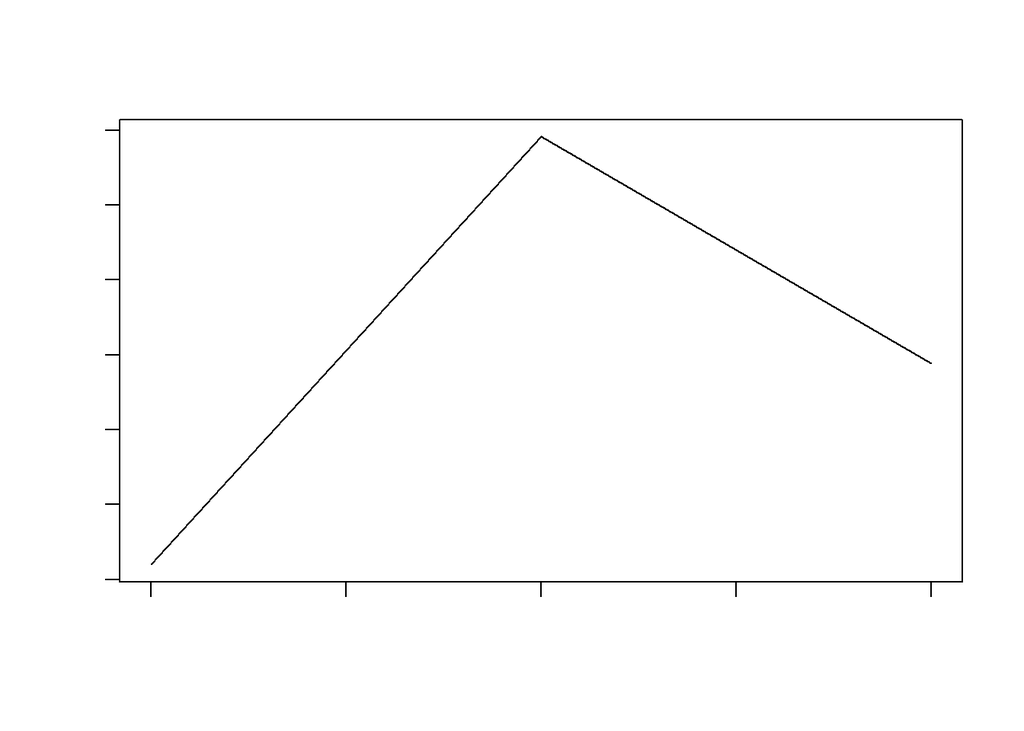

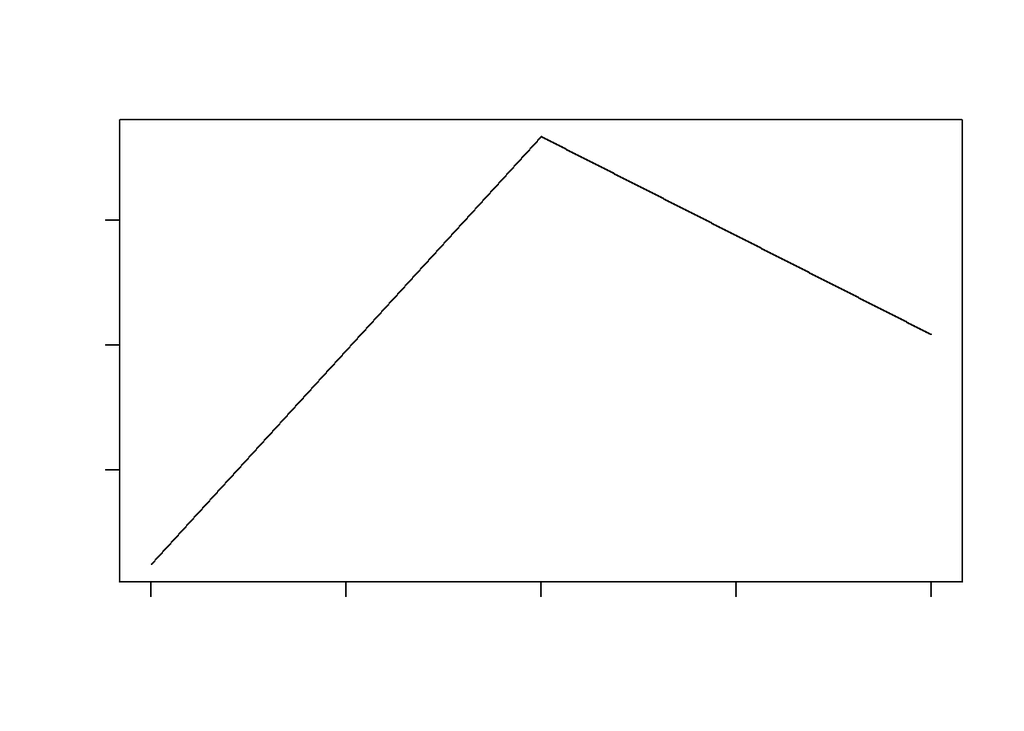

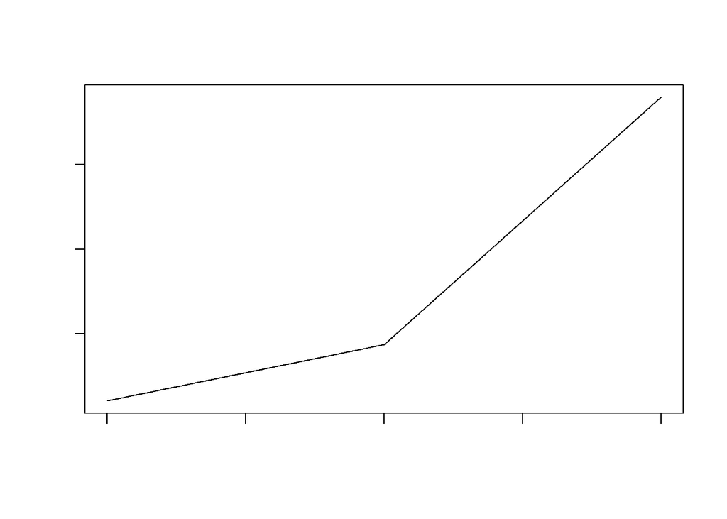

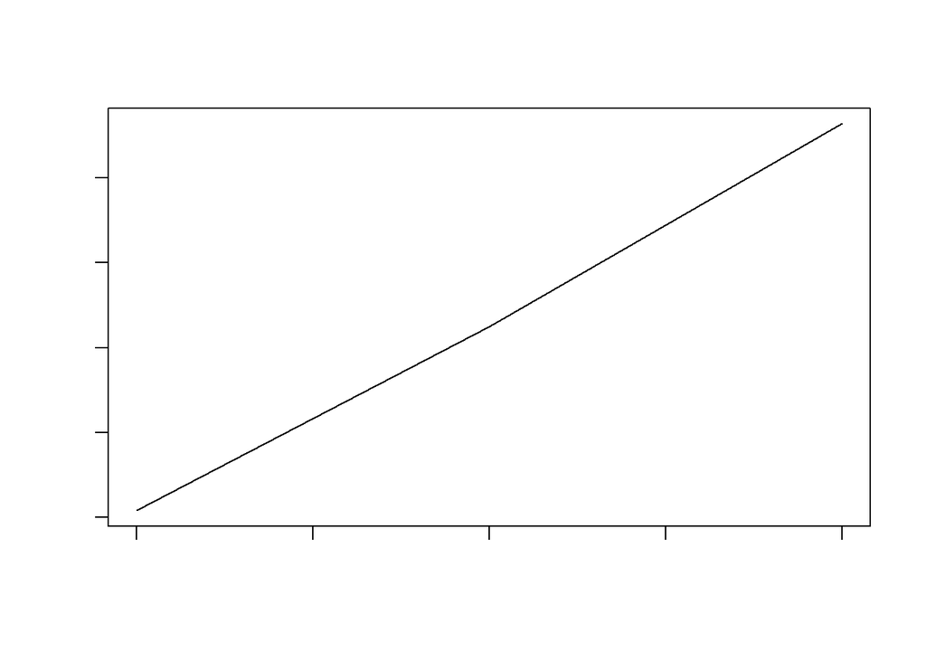

we have to add some labels lol but we can work on it after

v11 is by far the closest predictors, follows by v5, v3 is meh and everything else goes to shit from there

we will now plot the residual time series see how much we are off by

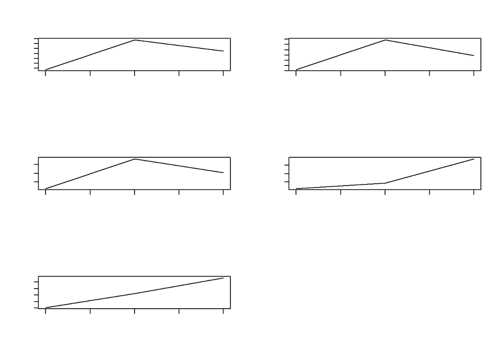

all centers at 0 but last 2, the second seems to have the smallest range which means its the best, so lets use the first three as our test

## random forest

random forest on all of cash flows nets, var imp plot doesnt want to work so we will address that in the plot

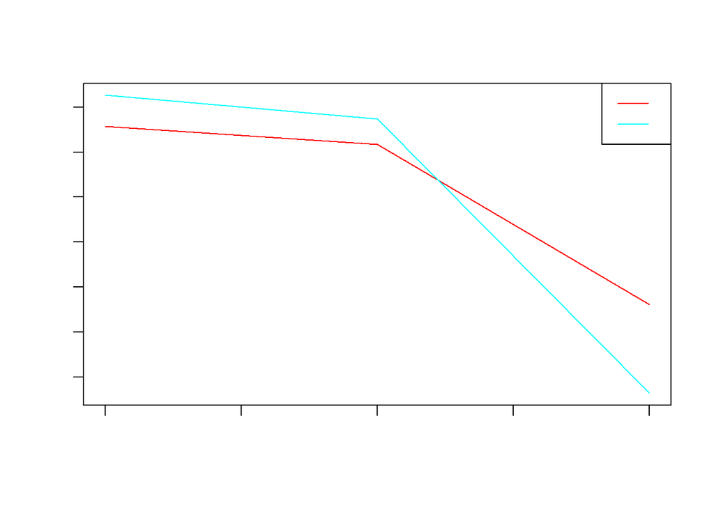

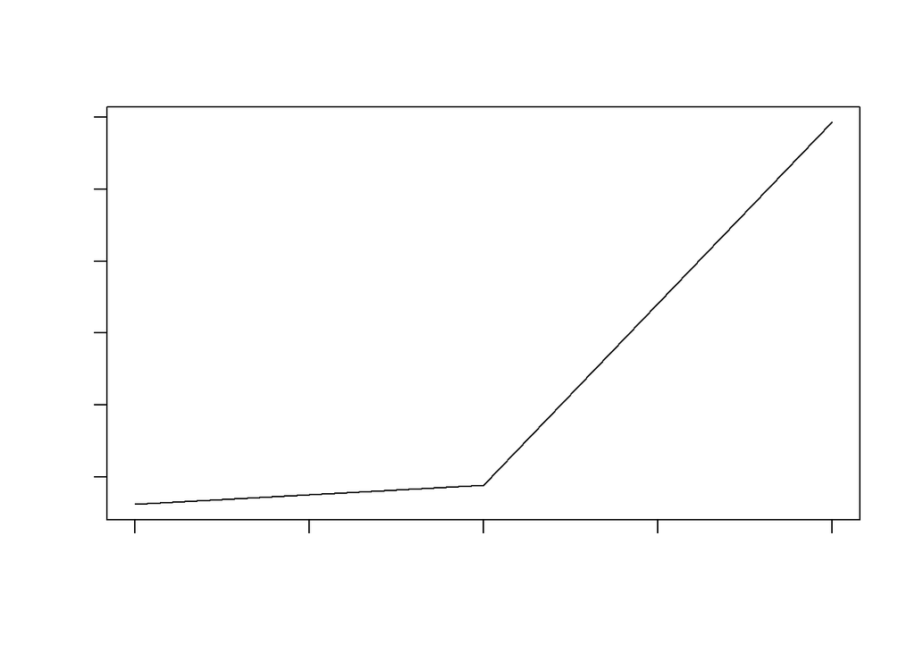

alot of varaiance so lets test on x

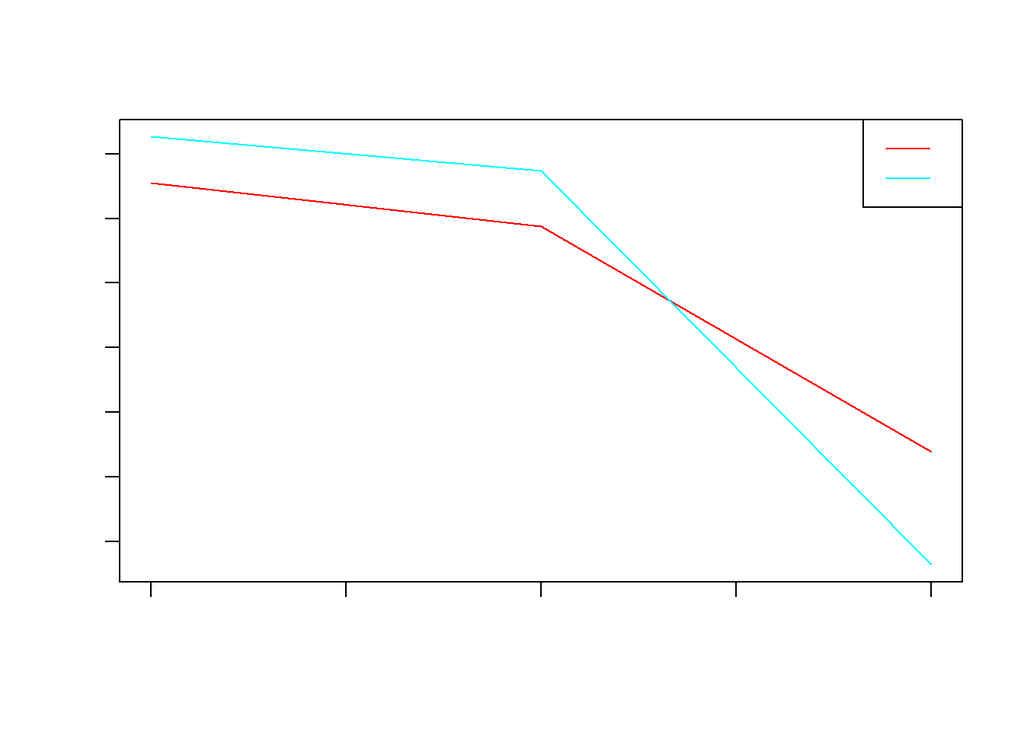

```
## [1] 3483.772
```

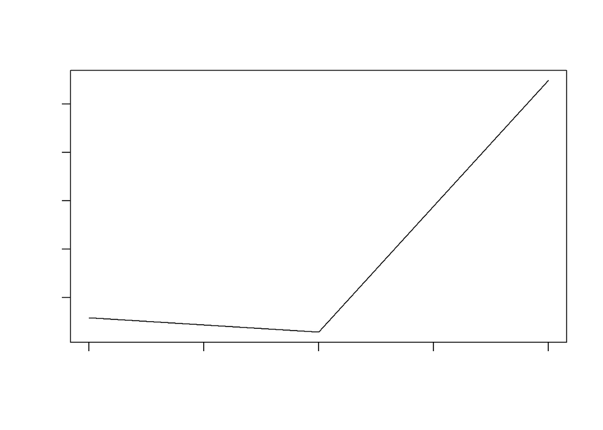

Running our random tree forest on our test: Having soe trouble working out the graphs for this

## testing / results

lets use the best fitted models on our training set

we will use fit 11, fit 3, fit 5, and both forests

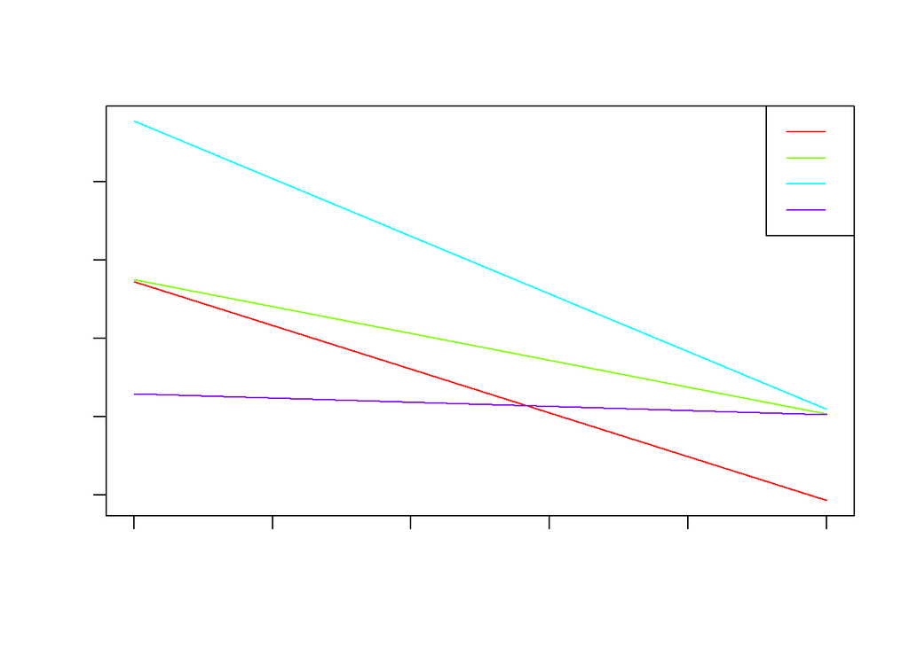

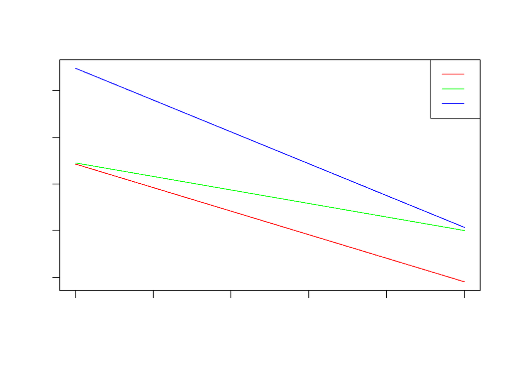

check forest

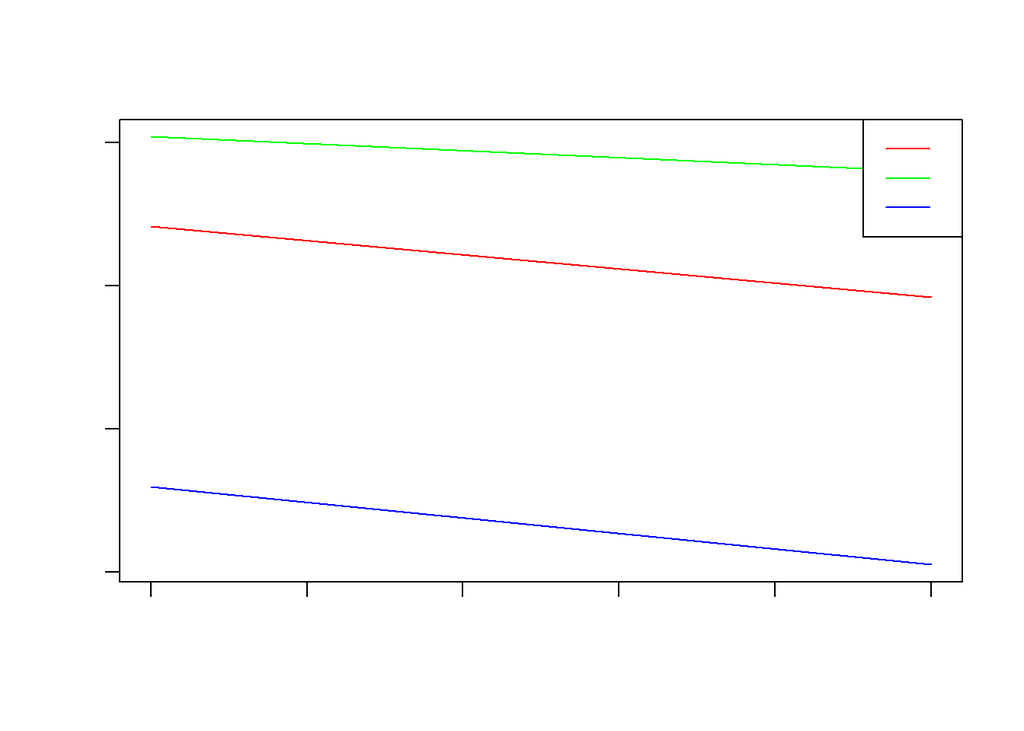

a lot of error

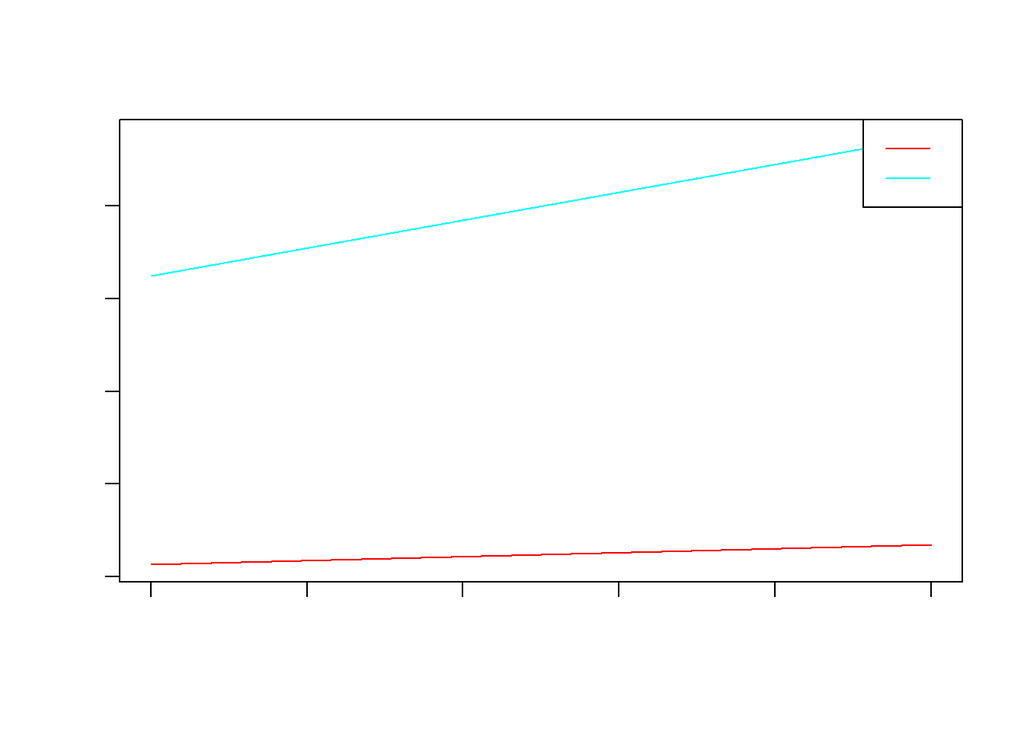

## conclusin

none of the models we got could really good predictors so we can conclude that there is no correlation with cashflow from other sources and cash flows from tutition and fees. make note that our data was weak given we only had 5 years to work with.